# Lab 4a: Logistic regerssion

Eser Comak

December 4, 2018

# The description of the experiment

The data that we will use in this lab session is from van Rij, van Rijn, & Hendriks (2010)1, who investigated children’s poor performance on pronoun interpretation by testing the predictions from computational simulations in an experiment with 4-6 years-old children. They were interested in the acquisition of object pronouns (e.g., ‘hem’ / him) and reflexives (e.g., ‘zichzelf’ / himself). In Dutch and English the pronoun (‘him’) is used to refer characters that are not the subject of the utterance, whereas a reflexive (‘himself’) can only refer to the subject. Two example sentences from the paper:

‘Here you see a penguin and a sheep. The penguin is hitting himsheep with a pan.’

‘Here you see a penguin and a sheep. The penguin is hitting himselfpenguin with a pan.’

The interesting phenomenon is that children use the correct form (i.e., the pronoun for referring to non-subject characters and the reflexive for reference to subject characters) from the age of 4, but have an un-adultlike comprehension until around 7 years old. This is the so-called Delay of Principle B Effect, or DPBE. (They generally perform adultlike on reflexives from the age of 3, both in comprehension and production.)

This study investigated the hypothsis that children who show this Delay of Principle B effect, may show un-adultlike comprehension because they are to slow to take into account the speaker’s perspective. So they have the knowledge and skills for adultlike performance, but they are just to slow. The experiment therefore tested children’s comprehension when presented with normal speech and slowed-down speech, to provide them more time for comprehension.

# Data prep

```r
#clean workspace
rm(list = ls())

#call libraries
#install.packages("plyr")
#install.packages("lme4")
#install.packages("plotfunctions")


library(plyr)
library(lme4)
library(plotfunctions)

#read in the csv datafile
dat <- read.table("C:/Users/eserc/Desktop/HMC/second year/Ib/Advanced statistical modelling/LRMEM/lab4a/data_vanRij.csv", fill = TRUE, sep = ",", header = TRUE)
# always immediately check whether the data looks as expected:
head(dat)
```

```
##   List TrialCode ID BlockN Gender AgeMnd Condition Version Type Nr  Answer
## 1   S2     S-6PG  2      1      m     54         S       2    P  6 CORRECT
## 2   S2     S-8RF  2      1      m     54         S       2    R  8   FALSE
## 3   S2     S-4PG  2      1      m     54         S       2    P  4 CORRECT
## 4   S2     S-5CF  2      1      m     54         S       2    C  5   FALSE
## 5   S2     S-5RF  2      1      m     54         S       2    R  5   FALSE
## 6   S2     S-1PF  2      1      m     54         S       2    P  1   FALSE
##   Accuracy Block TrialBlock Trial  Congruency Group
## 1        1     1          1     1   congruent  DPBE
## 2        1     1          2     2 incongruent  DPBE
## 3        1     1          3     3   congruent  DPBE
## 4        1     1          4     4 incongruent  DPBE
## 5        1     1          5     5 incongruent  DPBE
## 6        1     1          6     6 incongruent  DPBE
```

## Part I. Descriptive Statistics

# Data Inspection

```r
#count the number of unique subject entries in th data.frame
length(unique(dat$ID))
```

```
## [1] 62
```

```r
#checking if all participants complete the test
ddply(dat,c("ID"),summarise,ASD = length(TrialBlock))
```

```
##    ID ASD
## 1   2  40
## 2   3  40
## 3   5  40
## 4   6  40
## 5   7  40
## 6   8  40
## 7   9  40
## 8  10  40
## 9  11  40
## 10 12  40
## 11 13  40
## 12 14  40
## 13 15  40
## 14 16  40
```

[output cut: 48 more lines]

```r
#calculate age range
range(dat$AgeMnd)
```

```
## [1] 49 74
```

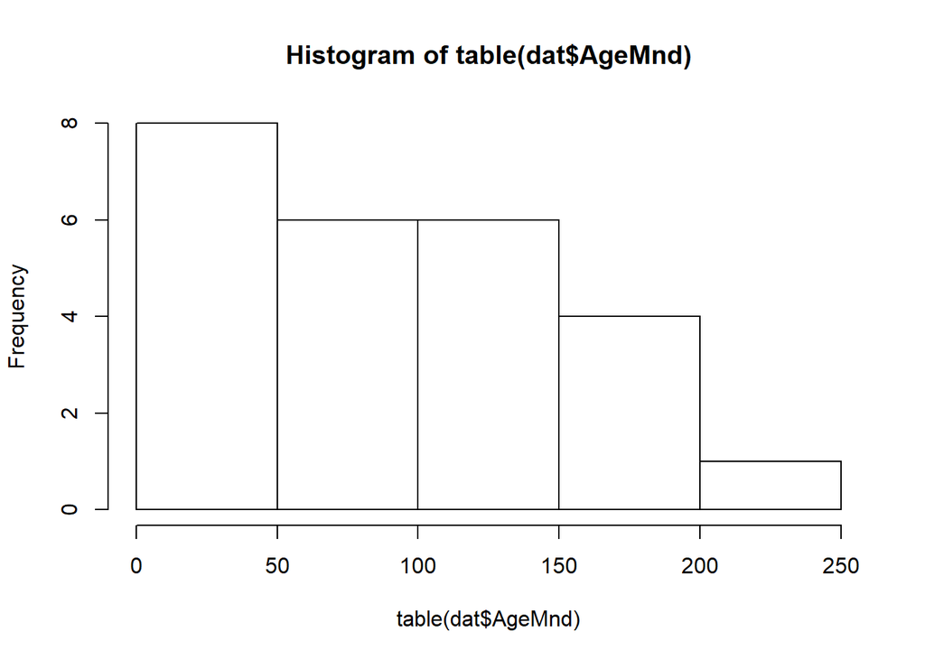

```r
#histogram age
hist(table(dat$AgeMnd))
```

How many participants are included in the data?  
**62** Did all participants complete the test?  
**Yes 40 of them. 20 blocks for each condition** Calculate the participants’ age range.  
**49 to 74** Visualize the distribution of participant age.  
**it looks like gamma dist**

# Answer biases

The column Congruency indicates whether the picture presented on the screen matched the interpretation of the sentence. If the picture was incongruent, the participants should have answered FALSE, if the picture was congruent they should have answered TRUE.

```r
#The following command prints the number of congruent and incongruent items that the participants saw:
table(dat$Congruency)
```

```
##
##   congruent incongruent
##        1240        1240
```

```r
#Now print a similar table for the children's answers:
table(dat$Answer)
```

```
##
## CORRECT   FALSE
##    1454    1023
```

What could you infer from these two tables about children’s answers? **children were probably not very successfull at catching incongruencies. Thus they had false positives. In other words, they were less successful in saying oh this incongruent picture is not matching the sentence.** What could you infer from these tables about children’s accuracy? **they were probably good with congruent stuff but not with incongruent case. so i would say their max mean accuracy was 0.825 for incongruent case**

# Experimental manipulations

In the experiment we tested children’s comprehension of pronouns (‘him’) and reflexives (‘himself’) in sentences produced in a normal speech rate and a slower speech rate. The predictors that implement these conditions are Type and Condition.

```r
#Inspect the columns Type and Condition.
str(dat$Type)
```

```
##  Factor w/ 3 levels "C","P","R": 2 3 2 1 3 2 3 2 1 2 ...
```

```r
str(dat$Condition)
```

```
##  Factor w/ 2 levels "N","S": 2 2 2 2 2 2 2 2 2 2 ...
```

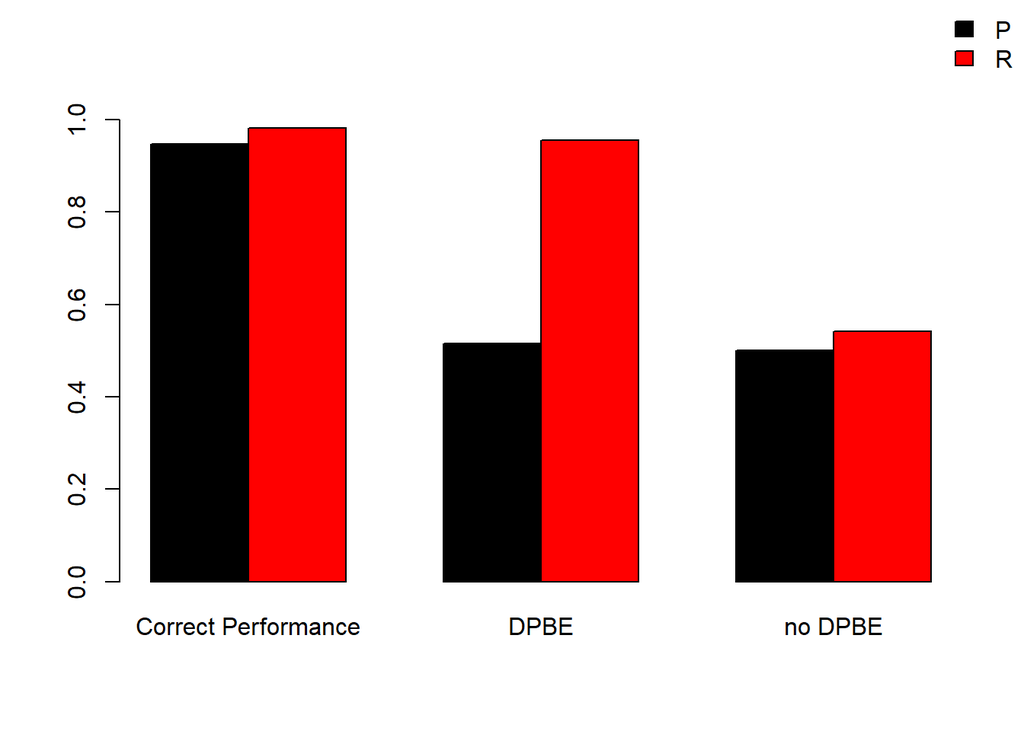

```r
#The level 'C' in column Type marks a control item, which we will remove from the data:

dat <- droplevels(dat[dat$Type != 'C',])

#Based on their performance in the normal speech rate condition, participants were divided into three different groups. The average accuracy per group in the normal speech rate condition is calculated and visualized below.

avg <- with(droplevels(dat[as.character(dat$Condition)=="N",]), tapply(Accuracy, list(Type, Group), mean))

barplot(avg, beside = TRUE, col=c(1,2), ylim=c(0,1))
legend_margin("topright", fill=c(1,2), legend=c("P","R"), bty='n')
```

Characterize the three groups based on the participant’s performance in the plots.

**R condition has higher correct responses overall compared to P condition.**

**In DPBE condition R is higher than P and in no DPBE condition R is still higher than P but compared to DPBE condition there is significant decrease in R condition accuracy rate. However between these conditions, P condition accuracy doesnt change almost at all.** dpbe might be too young to even have a signiFicant performance.

## Part II. Generalized Linear Model

# Q4.Conditions

Before starting with generalized linear mixed-effects models, we start the analysis with a generalized linear model (no random effects).

```r
#Fit a generalized linear model (glm with family=binomial) to the data. Include the predictors Condition, Type and Group and their interactions, and use Accuracy as dependent variable.
m1 <- glm(Accuracy ~ Condition*Type*Group , data=dat, family=binomial)
summary(m1)
```

```
##
## Call:
## glm(formula = Accuracy ~ Condition * Type * Group, family = binomial,
##     data = dat)
##
## Deviance Residuals:
##     Min       1Q   Median       3Q      Max
## -2.8374   0.1898   0.3318   0.7090   1.1774
##
## Coefficients:
##                               Estimate Std. Error z value Pr(>|z|)
## (Intercept)                     2.8717     0.4196   6.843 7.75e-12 ***
## ConditionS                     -1.5838     0.4788  -3.308 0.000940 ***
## TypeR                           1.1357     0.8277   1.372 0.170035
## GroupDPBE                      -2.8076     0.4347  -6.459 1.05e-10 ***
## Groupno DPBE                   -2.8717     0.4813  -5.966 2.43e-09 ***
## ConditionS:TypeR                0.2750     0.9438   0.291 0.770778
## ConditionS:GroupDPBE            1.7197     0.5051   3.405 0.000662 ***
## ConditionS:Groupno DPBE         1.5838     0.5834   2.715 0.006633 **
## TypeR:GroupDPBE                 1.8583     0.8790   2.114 0.034514 *
## TypeR:Groupno DPBE             -0.9686     0.8925  -1.085 0.277804
## ConditionS:TypeR:GroupDPBE     -1.2282     1.0140  -1.211 0.225800
## ConditionS:TypeR:Groupno DPBE   0.8107     1.0668   0.760 0.447280
## ---
## Signif. codes:  0 '***' 0.001 '**' 0.01 '*' 0.05 '.' 0.1 ' ' 1
##
## (Dispersion parameter for binomial family taken to be 1)
##
##     Null deviance: 2227.4  on 1980  degrees of freedom
## Residual deviance: 1782.3  on 1969  degrees of freedom
##   (3 observations deleted due to missingness)
## AIC: 1806.3
##
## Number of Fisher Scoring iterations: 6
```

What does the intercept represent? What does the value of the intercept indicates?

is the log of odds of accuracy value when type group is pronouns, playback speed(condition) is normal, and finally there is no delay of development when it comes to compherension of pronouns referring to non subject characters.

```r
#Before interpreting the model, check whether the three-way interaction is significantly contributing to the model:
m2 <- glm( Accuracy ~ Condition+Type+Group , data=dat, family=binomial)
# for logistic models include test='Chisq':
anova(m1, m2, test="Chisq")
```

```
## Analysis of Deviance Table
##
## Model 1: Accuracy ~ Condition * Type * Group
## Model 2: Accuracy ~ Condition + Type + Group
##   Resid. Df Resid. Dev Df Deviance  Pr(>Chi)
## 1      1969     1782.3
## 2      1976     1851.9 -7  -69.666 1.725e-12 ***
## ---
## Signif. codes:  0 '***' 0.001 '**' 0.01 '*' 0.05 '.' 0.1 ' ' 1
```

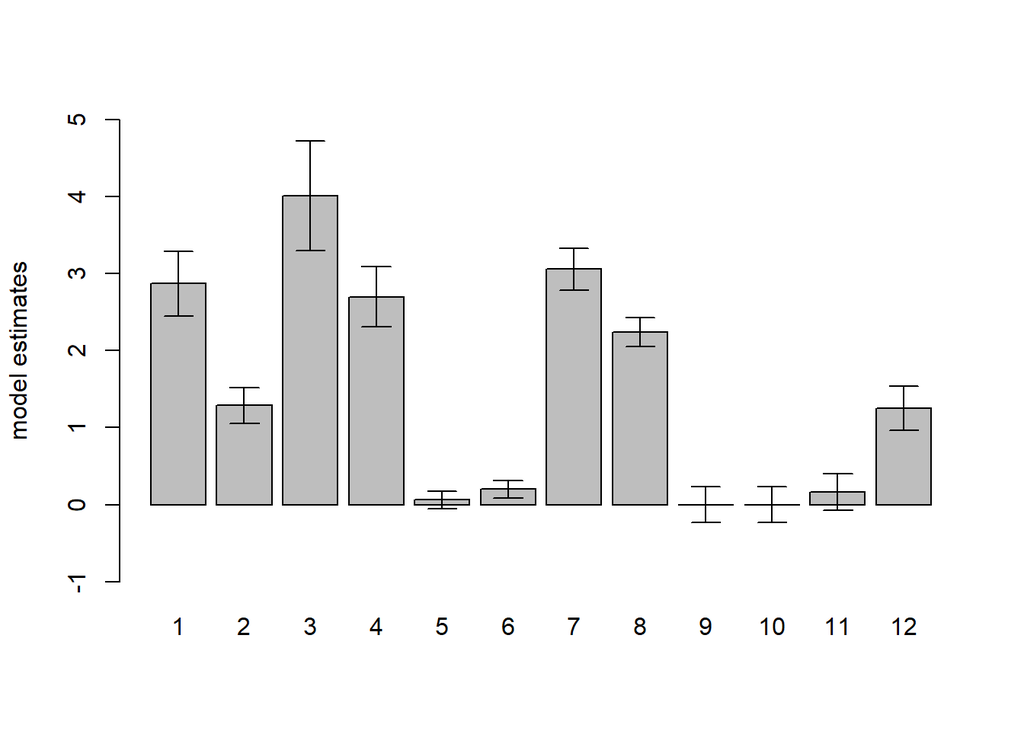

```r
#create combinations of conditions
require(utils)
newd <- expand.grid(Condition=c("N","S"),
                   Type=c("P", "R"),
                   Group=c("Correct Performance", "DPBE","no DPBE"))

#predict newd with m1 and plot it for 12 cond
predResults<-predict(m1, newd,se.fit=TRUE)

b <- barplot(predResults$fit, beside = TRUE,
        ylab="model estimates",
        ylim=c(-1,5), xpd=FALSE)
errorBars(b, predResults$fit, predResults$se.fit)
```

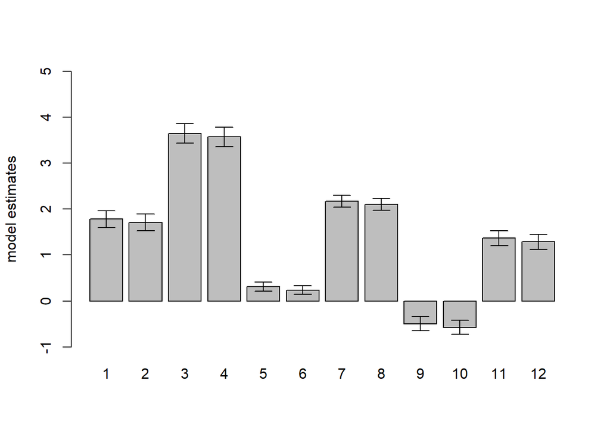

```r
#predict newd with m2 and plot it for 12 cond
predResults2<-predict(m2, newd,se.fit=TRUE)

c <- barplot(predResults2$fit, beside = TRUE,
        ylab="model estimates",
        ylim=c(-1,5), xpd=FALSE)
errorBars(c, predResults2$fit, predResults2$se.fit)
```

#ASK HERE# Which model is preferred? model with interactions is better because it captures existing interactions

Inspect the summaries of the most complex model. By adding up the right coefficients, try to calculate the total estimates for the 12 conditions. Alternatively, you could use the function predict. Based on the summary or predicted estimates from this model, do you think the model estimate a significant three-way interaction?

What is your conclusion: Is the three-way interaction significant?